TRUST BEFORE PASS · START HERE

# When can you trust a circuit measurement?

You have a saved simulation and a reported startup delay. Your job is to decide whether the delay can actually be measured, and whether the observed circuit response meets a stated rule. Those are two separate decisions.

**No programming is required.** Keep this page open as a reference. Read the example below, then open the experiment desk in a second tab. The four tasks use dropdowns and short written answers.

参加同学试用？先看中文操作与反馈说明

**Real recorded SPICE waveforms.** SPICE is a circuit simulator. This lesson replays saved simulation data. It does not measure a physical chip or run new simulations when you click a control. T1 below is an explicit teaching assumption, not the original designer’s established acceptance specification.

## 1. Read a normal startup

A power-on-reset circuit (POR) coordinates reset as power turns on. In this particular design the POR output is active high: when its voltage rises, reset is *asserted*. Reset release occurs later. The short record here does not show the entire nominal 50 ms reset pulse.

Read the graph from left to right. The horizontal axis is time in milliseconds (ms); 1 ms is one thousandth of a second. The vertical axis is voltage in volts (V).

- **AVDD:** the supply voltage rises from 0 to 3.3 V.
- **osc_ck:** the oscillator clock provides a timing reference. Its repeated pulses can look like a dense band at this scale.
- **POR assertion:** the reset output rises. Locate that change, rather than treating every high level as a new event.

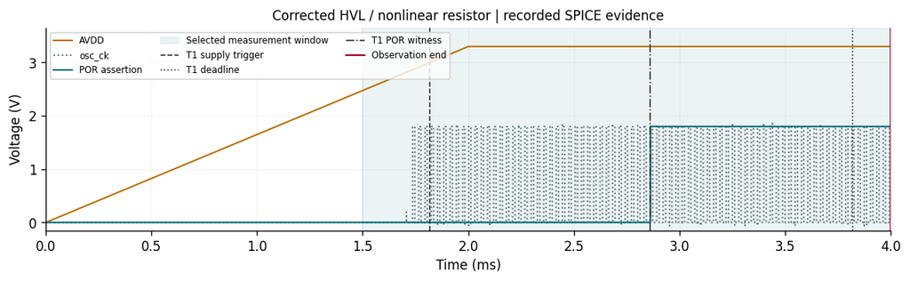

Source: corrected HVL library, original nonlinear resistor model, nominal tt process / 27 °C, AVDD ramp 2 ms, DVDD 1.8 V. This is the existing normal reference record; source hashes are available in the experiment desk. The known library correction is upstream work.

**Try before continuing:** point to the supply rise, the oscillator activity and POR assertion. What later behavior cannot be checked from a record ending at 4 ms?

## 2. Keep three questions separate

[output not shown]

The delay starts at an oscillator event; T1 starts at a supply event. The two checks can reach different conclusions. A simulator finishing successfully does not answer either question by itself.

**Observation matters:** distinguish “the response occurred,” “the deadline passed without it,” “we have not observed enough,” and “no supply trigger was observed.” Never turn missing evidence into a pass. T1 also assumes finite, ordered samples with gaps no larger than 2 µs; the saved evidence is checked for these conditions.

**Graph markers and model terms**

The shaded measurement window selects which oscillator and POR events count. The red line ends the visible observation. Gray space beyond it contains no observed data; it does not mean the voltage is zero. T1 trigger, deadline and witness lines use the legend’s labels.

HVL is the high-voltage cell-model library used in the simulator. We compare recorded “old” and “corrected” versions. A resistor model can be original (nonlinear) or simplified (linear). DC override means a testbench supply setting. These are separate controlled comparisons, not arbitrary new circuits.

## 3. Follow the investigation

1. **Observation window:** predict what a short view can establish, then compare a longer view of the same old-library record.
2. **Test a hypothesis:** choose an explanation and compare two cases differing in one controlled setting. Predict the second, lower plot.
3. **Measurement rules:** change a numerical limit on the same corrected record. Which judgment should change?
4. **Independent challenge:** interpret a less familiar observation, request the evidence you need and describe a check in ordinary words.

Each task follows: choose → predict with a reason → inspect evidence → explain → receive feedback. An uncertain or incorrect prediction is useful. You may write in Chinese or English. Written reasoning is retained but is not automatically graded.

**Open the experiment desk →**

**Keep the same experiment tab for all four tasks.** Switching conditions keeps written notes as unfinished drafts and preserves completed attempts. Closing or reloading loses page memory. Use **Download readable notes (.txt)** before leaving. The file stays on your device; nothing is uploaded.

After feedback, use the suggested next step. At the end, save your notes and complete the transfer question and comments in FEEDBACK_FORM.txt. Open that file in Notepad or any text editor; no code or special software is needed.

## If something does not work

- First extract the ZIP. Do not open pages from inside the compressed-file preview. Keep the files together.
- If a chat or Notebook preview shows a blank embedded page, open START_HERE.html from the extracted folder with your usual browser.
- If scripts cannot run, use the paper-and-evidence worksheet. Write before expanding each result. Mark your session as “static.” You can finish the reasoning tasks without Python.
- If a dropdown or feedback button seems blocked, read the message beside it. Predictions and a reason are required; feedback also needs your observation. The challenge additionally asks for your next evidence request and proposed check.
- If you are still blocked, record the page, action and exact message in the feedback form and stop that task. Do not install EDA tools or change security settings to complete the trial.

Development checks used a browser on local HTTP. Direct file opening has not yet been verified because the automation browser blocks file:// URLs. Your actual browser and entry mode are part of the trial record. Self-contained files do not imply every browser has been tested.

## What this work contributes — and its limits

The project organizes a real investigation and adds reusable checks for measurement prerequisites and a narrow functional rule. A known upstream HVL level-shifter fix explains the recorded dependency comparison; we did not discover a new POR defect or create that circuit fix. Root-cause reasoning here is manual and controlled.

This is one circuit with limited conditions, not broad PVT, silicon, full-pulse or brownout validation. A simple Python check agrees on the supported cases; no better detection rate is established. Independent reader feedback is still pending.

**Optional engineering path**

The complete candidate includes a seven-act Notebook, raw data and an independent Python API. CACE is an open-source characterization tool; our existing integration uses its script hooks. You do not need to install it for this lesson. The separate T1 result is not a new native CACE status. Ask the author for the full candidate if you received only the compact reader pack.